# Ex1_Climate

```python
from google.colab import drive
drive.mount('/content/drive')
```

```python
import pandas as pd
import numpy as np
import matplotlib.pyplot as plt


daily_data = pd.read_csv('/content/drive/MyDrive/Uni Projects/new_isr_daily_data_web.csv')
stations_table = pd.read_csv('/content/drive/MyDrive/Uni Projects/new_stn_table_web.csv')
```

```python
# Filter stations based on operational history
long_history_stations = stations_table[(stations_table['date_open'].notnull()) & (stations_table['date_close'].isnull())]

# Check which stations have data in the daily_data dataset
stations_with_data = long_history_stations[long_history_stations['stn_num'].isin(daily_data['stn_num'].unique())]

# Selecting the first station with data
selected_station = stations_with_data.iloc[0]

print("Selected Station:")
print(selected_station["stn_name"])
```

```
Selected Station:
ROSH HANIQRA
```

Q1: Plot the maximum and minimum daily temperature.

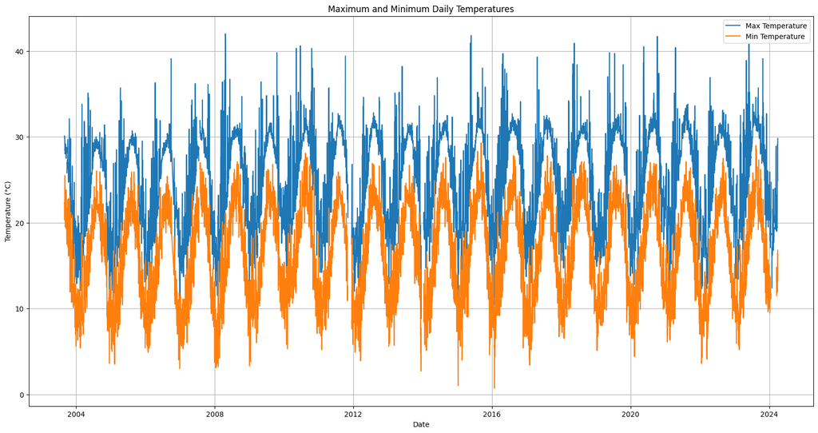

```python
# Filter daily data for the selected station
selected_station_data = daily_data[daily_data['stn_num'] == selected_station['stn_num']].copy()

# Convert 'time_obs' to datetime format using .loc accessor
selected_station_data.loc[:, 'time_obs'] = pd.to_datetime(selected_station_data['time_obs'])

# Create a figure for the first plot (Maximum and Minimum Daily Temperatures)
plt.figure(figsize=(20, 10))
plt.plot(selected_station_data['time_obs'], selected_station_data['tmp_air_max'], label='Max Temperature')
plt.plot(selected_station_data['time_obs'], selected_station_data['tmp_air_min'], label='Min Temperature')
plt.xlabel('Date')
plt.ylabel('Temperature (°C)')
plt.title('Maximum and Minimum Daily Temperatures')
plt.legend()
plt.grid(True)
plt.show()
```

Q2: Plot the daily amplitude.

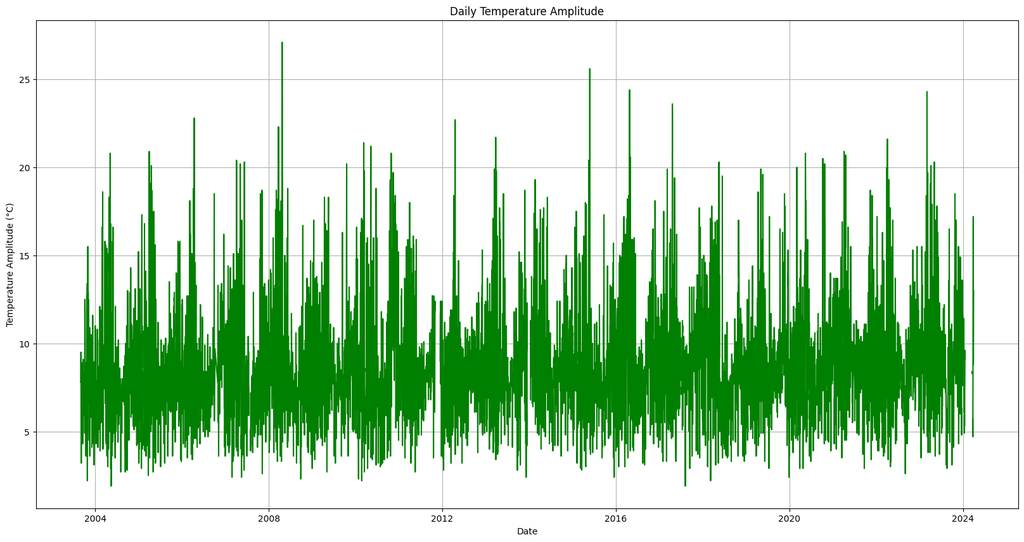

```python
# Calculate daily temperature amplitude
selected_station_data['temperature_amplitude'] = selected_station_data['tmp_air_max'] - selected_station_data['tmp_air_min']

# Create a figure for the second plot (Daily Temperature Amplitude)
plt.figure(figsize=(20, 10))
plt.plot(selected_station_data['time_obs'], selected_station_data['temperature_amplitude'], color='green')
plt.xlabel('Date')
plt.ylabel('Temperature Amplitude (°C)')
plt.title('Daily Temperature Amplitude')
plt.grid(True)
plt.show()
```

Q3: Choose 15 consecutive days from a certain year and draw the maximum temperature. Is there any similarity between those day?

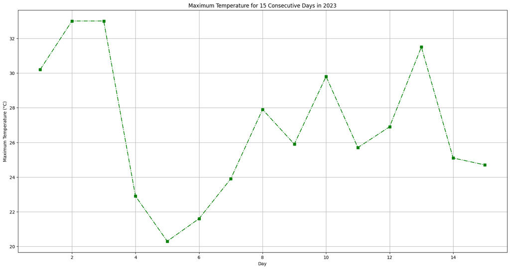

```python
# Choose the year for analysis
selected_year = 2023  # Change this to the desired year

# Filter daily data for the selected year
data_selected_year = daily_data[daily_data['year'] == selected_year]

# Assuming we start from the first day of the year, find the index of the first day of the 15-day period
start_index = data_selected_year.index[0]

# Extract the maximum temperature for the 15-day period
max_temp_15_days = data_selected_year.iloc[start_index:start_index + 15]['tmp_air_max']

# Plot the maximum temperature for the 15 consecutive days
plt.figure(figsize=(20, 10))
plt.plot(range(1, 16), max_temp_15_days, marker='s', linestyle='-.', color = 'green')
plt.xlabel('Day')
plt.ylabel('Maximum Temperature (°C)')
plt.title('Maximum Temperature for 15 Consecutive Days in {}'.format(selected_year))
plt.grid(True)
plt.show()
```

All those 15 days are between 20 - 33 °.

There is simmiliraty between a day and the day before but we cant see a radical changes except for day 3 to 4 when the difference is 10 °.

Q4: Choose 10 years and draw the maximum temperature of those 15 days, are those graphs look the same?

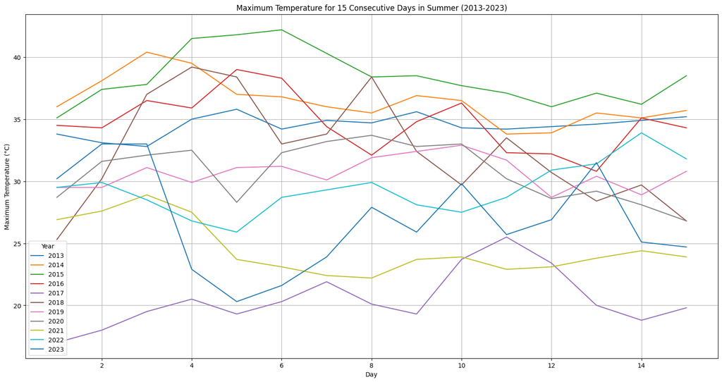

```python
# Choose the range of years for analysis
start_year = 2013
end_year = 2023  # Adjust as needed

# Create a figure for the plot
plt.figure(figsize=(20, 10))

# Lists to store years and corresponding seasons
years = []
seasons = []

# Loop through each year in the range
for year in range(start_year, end_year+1):
    # Filter daily data for the selected year
    data_selected_year = daily_data[daily_data['year'] == year]

    # Assuming we start from the first day of the year, find the index of the first day of the 15-day period
    start_index = data_selected_year.index[0]

    # Extract the maximum temperature for the 15-day period if data is available
    if len(data_selected_year) >= start_index + 15:
        max_temp_15_days = data_selected_year.iloc[start_index:start_index + 15]['tmp_air_max']

        # Determine the month of the first day in the 15-day period
        start_month = data_selected_year.iloc[start_index]['month']

        # Determine the season based on the start month
        season = 'Winter' if start_month in [12, 1, 2] else 'Summer'

        # Plot the maximum temperature for the 15 consecutive days
        plt.plot(range(1, 16), max_temp_15_days, label=str(year))

        # Append year and season to the lists
        years.append(year)
        seasons.append(season)

# Determine if all seasons are the same
same_season = all(season == seasons[0] for season in seasons)

# Title of the plot
if same_season:
    title = f'Maximum Temperature for 15 Consecutive Days in {seasons[0]} ({min(years)}-{max(years)})'
else:
    title = f'Maximum Temperature for 15 Consecutive Days ({min(years)}-{max(years)})'

# Add labels and title to the plot
plt.xlabel('Day')
plt.ylabel('Maximum Temperature (°C)')
plt.title(title)
plt.legend(title='Year')
plt.grid(True)
plt.show()
```

Q5: Repeat the question with 15 days from another period of time. Are the graphs look the same?

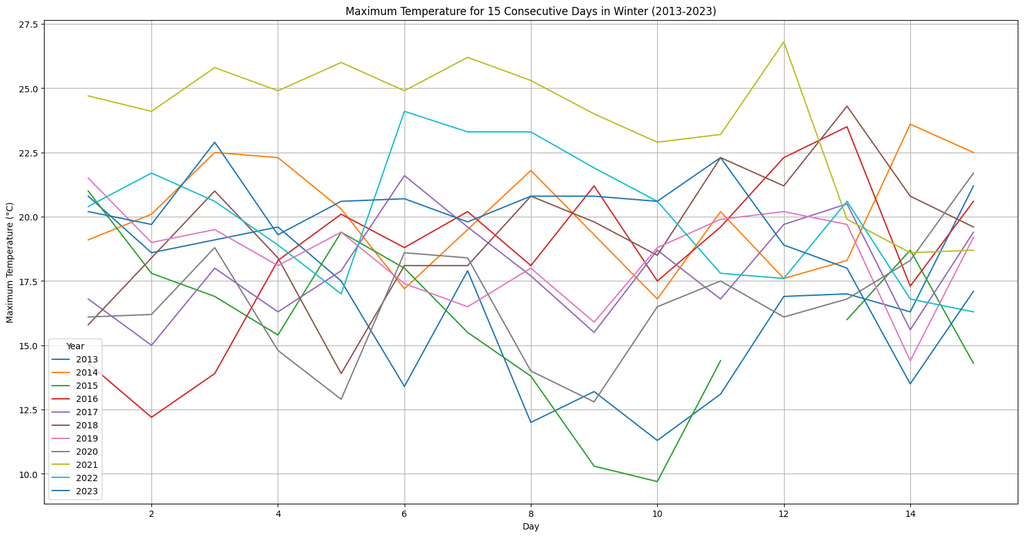

```python
# Choose the range of years for analysis
start_year = 2013
end_year = 2023  # Adjust as needed

# Create a figure for the plot
plt.figure(figsize=(20, 10))

# Lists to store years and corresponding seasons
years = []
seasons = []

# Loop through each year in the range
for year in range(start_year, end_year+1):
    # Filter daily data for the selected year
    data_selected_year = daily_data[daily_data['year'] == year]

    # Extract the maximum temperature for the winter months (December, January, February)
    winter_data = data_selected_year[(data_selected_year['month'] == 12) | (data_selected_year['month'] == 1) | (data_selected_year['month'] == 2)]

    # Check if there's enough data for 15 consecutive days in winter
    if len(winter_data) >= 15:
        # Extract the maximum temperature for the first 15 days
        max_temp_15_days = winter_data.head(15)['tmp_air_max']

        # Plot the maximum temperature for the 15 consecutive days
        plt.plot(range(1, 16), max_temp_15_days, label=str(year))

        # Append year to the list
        years.append(year)

# Title of the plot
title = f'Maximum Temperature for 15 Consecutive Days in Winter ({start_year}-{end_year})'

# Add labels and title to the plot
plt.xlabel('Day')
plt.ylabel('Maximum Temperature (°C)')
plt.title(title)
plt.legend(title='Year')
plt.grid(True)
plt.show()
```

Q5: Choose 4 dates - day & month : one for each of the seasons. Draw the temperature distribution of this day over many years

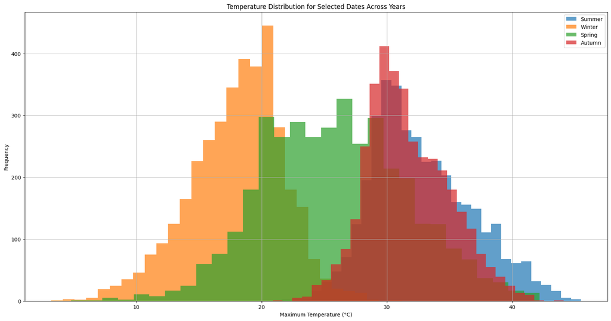

```python
# Define dates for each season
dates_by_season = {
    'Summer': {'month': 7, 'day': 15},  # Summer solstice
    'Winter': {'month': 12, 'day': 15},  # Winter solstice
    'Spring': {'month': 4, 'day': 15},   # Spring equinox
    'Autumn': {'month': 9, 'day': 15}    # Autumn equinox
}

# Create a figure for the plot
plt.figure(figsize=(20, 10))

# Loop through each season
for season, date in dates_by_season.items():
    # Filter daily data for the selected date across all years
    data_selected_date = daily_data[(daily_data['month'] == date['month']) & (daily_data['day'] == date['day'])]

    # Extract maximum temperatures for the selected date
    max_temperatures = data_selected_date['tmp_air_max']

    # Plot temperature distribution for the selected date
    plt.hist(max_temperatures, bins=30, alpha=0.7, label=season)

# Add labels and title to the plot
plt.xlabel('Maximum Temperature (°C)')
plt.ylabel('Frequency')
plt.title('Temperature Distribution for Selected Dates Across Years')
plt.legend()
plt.grid(True)
plt.show()
```

Summer centered at around 31(°C)

Winter centered at around 17(°C)

Autumn centered at around 30(°C)

Now i will perform the Shapiro-Wilk test for each dataset to determine whether it is normally distributed more formally

```python
from scipy.stats import shapiro

# Loop through each season
for season, date in dates_by_season.items():
    # Filter daily data for the selected date across all years
    data_selected_date = daily_data[(daily_data['month'] == date['month']) & (daily_data['day'] == date['day'])]

    # Extract maximum temperatures for the selected date
    max_temperatures = data_selected_date['tmp_air_max']

    # Perform Shapiro-Wilk test for normality
    stat, p = shapiro(max_temperatures)
    is_normal = p > 0.05

    # Calculate mean and standard deviation
    mean_temp = max_temperatures.mean()
    std_dev_temp = max_temperatures.std()

    # Print results
    print(f"{season}: {'Normally distributed' if is_normal else 'Not normally distributed'} "
          f"(p-value: {p:.4f}), μ = {mean_temp:.2f}, σ = {std_dev_temp:.2f}")
    print("---------------------------------------------------------------------")
```

[output not shown]